# STA 317 Exam 1

Scott Girten

October 14, 2019

## Problem 1

*Consider the random variables Y1 and Y2, where E(Y1) = 1, var(Y1) = 9, E(Y2) = 2, var(Y2) = 16, and cov(Y1, Y2) = -2. Find the following (values), showing all your steps: (20 points)*

### Part A

$$\begin{eqnarray}
var(Y_1 + Y_2) & = & var(Y_1) + var(Y_2) + 2cov(Y_1, Y_2) \\
& = & 9 + 16 + 2(-2) \\
& = & 21
\end{eqnarray}$$

### Part B

$$\begin{eqnarray}
cov(Y_1, 2Y_1 + 3Y_2) & = & cov(Y_1, 2Y_1) + cov(Y_1, 3Y_2) \\
& = & 2cov(Y_1, Y_1) + 3cov(Y_1, Y_2) \\
& = & 2var(Y_1) + 3cov(Y_1, Y_2) \\
& = & 2(9) + 3(-2) \\
& = & 12
\end{eqnarray}$$

### Part C

$$\begin{eqnarray}
corr(2Y_1 + 3Y_2, Y_1 - 2Y_2) & = & \frac{cov(2Y_1 + 3Y_2, Y_1 - 2Y_2)}{\sqrt{var(2Y_1 + 3Y_2)var(Y_1 - 2Y_2)}}
\end{eqnarray}$$

**Numerator**

$$\begin{eqnarray}
cov(2Y_1 + 3Y_2, Y_1 - 2Y_2) & = & cov(2Y_1, Y_1) + cov(2Y_1, -2Y_2) + cov(3Y_2, Y_1) + cov(3Y2, -2Y_2) \\
& = & 2cov(Y_1, Y_1) + (-4)cov(Y_1, Y_2) + 3cov(Y_2, Y_1) + (-6)cov(Y_2, Y_2) \\
& = & 2var(Y_1) + (-4)cov(Y_1, Y_2) + 3cov(Y_2, Y_1) + (-6)var(Y_2) \\
& = & 2(9) + (-4)(-2) + 3(-2) + (-6)(16) \\
& = & -76
\end{eqnarray}$$

**Denominator**

$$\begin{eqnarray}
var(2Y_1 + 3Y_2) & = & var(2Y_1) + var(3Y_1) + 2cov(2Y_1, 3Y_2) \\
& = & 4var(Y_1) + 9var(Y_2) + 2(2)(3)cov(Y_1, Y_2) \\
& = & 4(9) + 9(16) + 12(-2) \\
& = & 156
\end{eqnarray}$$

$$\begin{eqnarray}
var(Y_1 - 2Y_2) & = & var(Y_1) + var(-2Y_2) - 2cov(Y_1, -2Y_2) \\
& = & var(Y_1) + 4var(Y_2) - 2(-2)cov(Y_1, Y_2) \\
& = & 9 + 4(16) - (-4)(-2) \\
& = & 65
\end{eqnarray}$$

**Put it all together**

$$\begin{eqnarray}
corr(2Y_1 + 3Y_2, Y_1 - 2Y_2) & = & \frac{-76}{\sqrt{(156)(65)}} \\
& = & -0.7547352
\end{eqnarray}$$

## Problem 2

*Let $e_1, e_2, ...$ be a sequence of independent and identically distributed random variables with a mean of 0 and a constant variance $\sigma_e^2$. Define the time series $Y_t = \frac{2}{3}e_t + \frac{1}{3}e_{t-1}$*

*Find the complete structure of the series by deriving the following components: You must show work to justify your findings.*

### Part A

$$\begin{eqnarray}
E(Y_t) & = & E(\frac{2}{3}e_t) + E(\frac{1}{3}e_{t_1}) \\
& = & \frac{2}{3}E(e_t) + \frac{1}{3}E(e_{t-1}) \\
& = & \frac{2}{3}(0) + \frac{1}{3}(0) \\
& = & 0
\end{eqnarray}$$

### Part B

$$\begin{eqnarray}
var(Y_t) & = & var(\frac{2}{3}e_t) + var(\frac{1}{3}e_{t-1}) \\
& = & \frac{4}{9}var(e_t) + \frac{1}{9}var(e_{t-1}) \\
& = & \frac{5}{9}\sigma_e^2
\end{eqnarray}$$

### Part C

$$\begin{eqnarray}
cov(Y_t, Y_{t-1}) & = & cov\Big[\Big(\frac{2}{3}e_t + \frac{1}{3}e_{t-1}\Big), \Big(\frac{2}{3}e_{t-1} + \frac{1}{3}e_{t-2}\Big)\Big] \\
& = & cov(\frac{2}{3}e_t, \frac{2}{3}e_{t-1}) + cov(\frac{2}{3}e_t, \frac{1}{3}e_{t-2}) + cov(\frac{1}{3}e_{t-1}, \frac{2}{3}e_{t-1}) + cov(\frac{1}{3}e_{t-1}, \frac{1}{3}e_{t-2}) \\
& = & 0 + 0 + (\frac{1}{3})(\frac{2}{3})cov(e_{t-1}, e_{t-1}) + 0 \\
& = & \frac{2}{9}var(e_{t-1}) \\
& = & \frac{2}{9}\sigma_e^2
\end{eqnarray}$$

Since the random variables *e* are independent, the covariance is 0 for different *e* terms. Only terms with a common *e* will have covariance.

### Part D

$$\begin{eqnarray}
cov(Y_t, Y_{t-2}) & = & cov\Big[\Big(\frac{2}{3}e_t + \frac{1}{3}e_{t-1}\Big), \Big(\frac{2}{3}e_{t-2} + \frac{1}{3}e_{t-3}\Big)\Big] \\
& = & cov\Big(\frac{2}{3}e_t, \frac{2}{3}e_{t-2}\Big) + cov\Big(\frac{2}{3}e_t, \frac{1}{3}e_{t-3}\Big) + cov\Big(\frac{1}{3}e_{t-1}, \frac{2}{3}e_{t-2}\Big) + cov\Big(\frac{1}{3}e_{t-1}, \frac{1}{3}e_{t-3}\Big) \\
& = & 0 + 0 + 0 + 0
\end{eqnarray}$$

For value of $K \geq 2$, the covariance for terms in this times series will be zero since the terms will not share a common term as defined by the series.

### Part E

*Based on your results, is this process (weakly) stationary or not? Justify your response.*

This process is weakly stationary since the $E(Y_t)$ is constant for the series and the covariance for the series is does not depend on the value of $t$. The covariance is only dependent on the lag of $k$ and is constant throughout the series.

## Problem 3

*Let $e_1, e_2, ...$ be a sequence of independent and identically distributed random variables with a mean of 0 and a constant variance $\sigma_e^2$. Define the time series $Y_t = e_t - \frac{13}{15}e_{t-1} - \frac{26}{75}e_{t-2} + \frac{8}{25}e_{t-3}$*

### Part A

*Is this process invertible or not? (Why/Why not?) Justify your answer.*

This process is invertible since the roots of the characteristic equation are greater than $\lvert 1 \rvert$.

$$\begin{eqnarray}
1 - \frac{4}{5}x & = & 0 \\
\frac{4}{5}x & = & 1 \\
x & = & \frac{5}{4}
\end{eqnarray}$$

$$\begin{eqnarray}
1 - \frac{2}{3}x & = & 0 \\
\frac{2}{3}x & = & 1 \\
x & = & \frac{3}{2}
\end{eqnarray}$$

$$\begin{eqnarray}
1 + \frac{3}{5}x & = & 0 \\
\frac{3}{5}x & = & -1 \\
x & = & -\frac{5}{3}
\end{eqnarray}$$

### Part B

*Calculate the autocorrelation function (just the values $\rho 1, \rho 2, \rho 3$ and $\rho 4$). These are the theoretical values.*

```r
denominator = 1 + (13/15)^2 + (26/75)^2 + (-1*8/25)^2

theta1 = 13/15
theta2 = 26/75
theta3 = -1*8/25

rho_1 = (-1*theta1 + theta1*theta2 + theta2*theta3) / denominator
rho_2 = (-1*theta2 + theta2*theta3) / denominator
rho_3 = (-1*theta3) / denominator
rho_4 = 0
```

**Theoretical Values for $\rho 1$ to $\rho 4$**

$\rho 1$ = -0.3430913

$\rho 2$ = -0.2318501

$\rho 3$ = 0.1621329

$\rho 4$ = 0

### Part C

*Sketch the correlogram (lags 1-4 only) for this series based on the theoretical values. You can do this by hand on paper or using technology.*

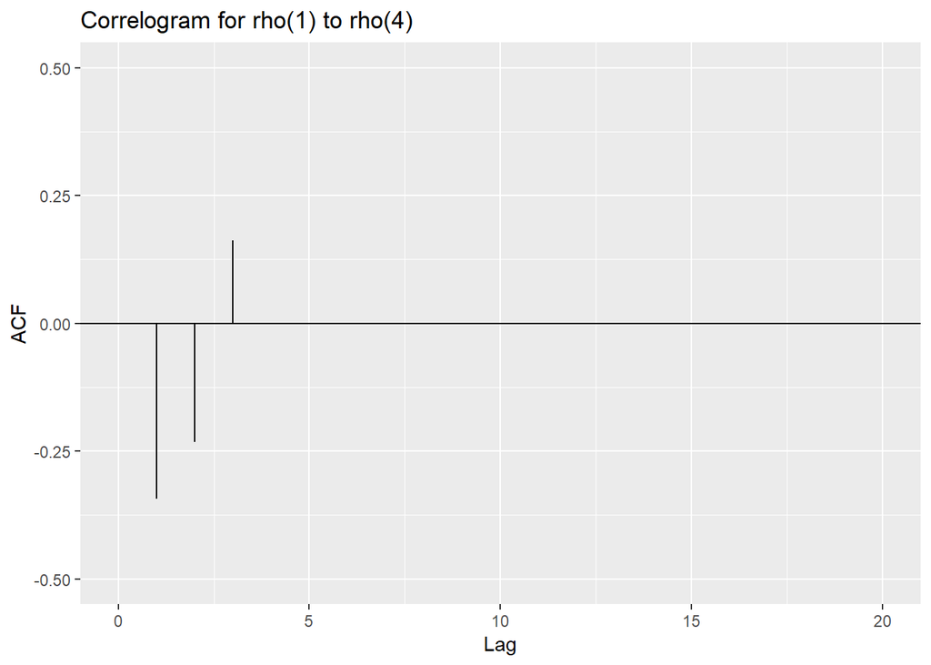

```r
library(tidyverse)


corr_plot = ggplot() +
  geom_segment(aes(x = 1, y = 0, xend = 1, yend = rho_1)) +
  geom_segment(aes(x = 2, y = 0, xend = 2, yend = rho_2)) +
  geom_segment(aes(x = 3, y = 0, xend = 3, yend = rho_3)) +
  scale_x_discrete() +
  xlim(min = 0, max = 20) +
  ylim(min = -0.5, max = 0.5) +
  geom_hline(yintercept = 0) +
  xlab("Lag") +
  ylab("ACF") +
  ggtitle("Correlogram for rho(1) to rho(4)")


plot(corr_plot)
```

## Problem 4

*The data file test1A.dat has a series with 200 data values. You should save this file – I suggest on your roaming drive. If my file is on the j: drive in a folder named STA317, then I can read the data into R using yvalues <- scan(“j:/STA317/test1A.dat”). This will read the values in the variable named yvalues. (30 points)*

### Part A

*First, fit a simple linear model assuming the predictor is a simple time index (x <-1:200). Give the estimated y-intercept and slope values from the linear model fit.*

```r
#Read data and add index to data frame
model_data = as.tibble(scan("test1A.dat")) %>%
  mutate(index = 1:200)

#Fit the model
model_fit = lm(value~index, data = model_data)
model_fit
```

```
##
## Call:
## lm(formula = value ~ index, data = model_data)
##
## Coefficients:
## (Intercept)        index
##      14.319        1.501
```

The y-intercept is 14.319 and the slope is 1.501

### Part B

*Use the residuals, or the $X_t$ values from $Y_t = U_t + X_t$ where $U_t$ is the line you fit from part A. First, create a plot of the residuals. Does there seem to be a violation of the independence assumption based on this plot? Why or why not?*

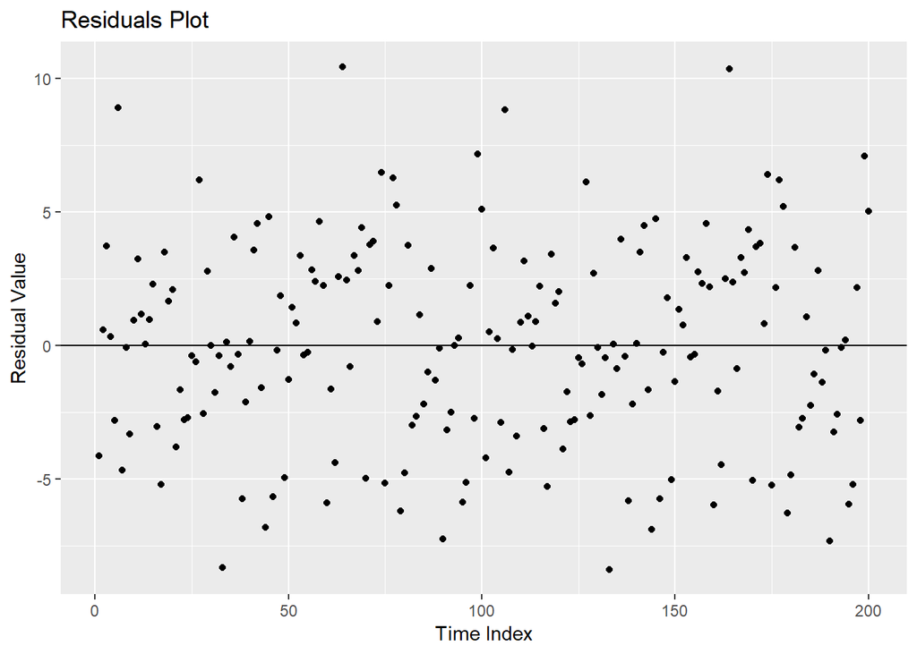

```r
#Create residual data frame
residuals = model_fit$residuals
index = 1:200
resid_tibble = tibble(index, residuals)


#Residual plot
resid_plot = ggplot(resid_tibble, aes(x = index, y = residuals)) +
  geom_point() +
  geom_hline(yintercept = 0) +
  xlab("Time Index") +
  ylab("Residual Value") +
  ggtitle("Residuals Plot")

plot(resid_plot)
```

There does not appear to be a violation of the assumption of independence from the residuals. The residuals form a channel and appear to have a constant variance throughout the channel.

### Part C

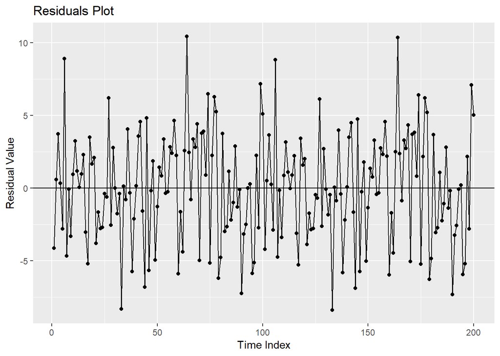

```r
runs_plot = resid_plot +
  geom_line()
plot(runs_plot)
```

**Output of the Runs Function**

```r
library(TSA)
runs_test = runs(residuals)
runs_test
```

```
## $pvalue
## [1] 0.36
##
## $observed.runs
## [1] 94
##
## $expected.runs
## [1] 100.96
##
## $n1
## [1] 102
##
## $n2
## [1] 98
##
## $k
## [1] 0
```

```r
numerator = 2 * (runs_test$n1 * runs_test$n2) * (2 * (runs_test$n1 * runs_test$n2) - 200)
denominator = 200 * 200 * (200 - 1)

sigma_runs =  sqrt(numerator / denominator)

runs_z_score = abs(runs_test$observed.runs - runs_test$expected.runs) / sigma_runs
```

$H_o:$ The residuals are independent

$H_a:$ The residuals are not independent

$\alpha = 0.025$

**Z-score:** 0.987172

**p-value:** 0.36

**Summary:** With a Z-score of 0.987172 and a p-value of 0.36, there is not sufficient evidence to reject the assumption of independence.

### Part D

*Complete a normality test on the residuals.*

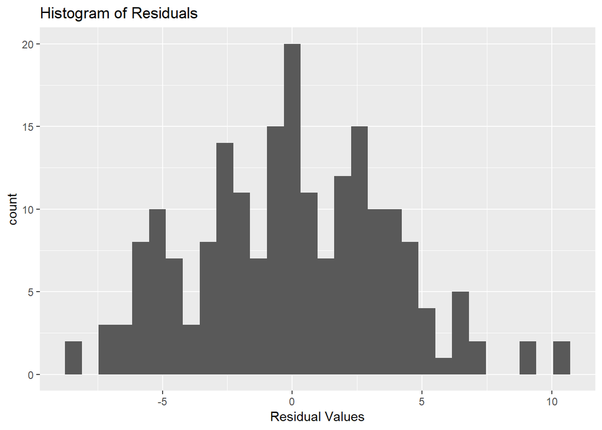

```r
resid_hist = ggplot(resid_tibble, aes(residuals)) +
  geom_histogram() +
  xlab("Residual Values") +
  ggtitle("Histogram of Residuals")
plot(resid_hist)
```

The histogram of the residuals does not provide evidence to contradict the assumption of normality.

```r
shap_wilk_test = shapiro.test(residuals)
shap_wilk_test
```

```
##
##  Shapiro-Wilk normality test
##
## data:  residuals
## W = 0.99032, p-value = 0.1992
```

**Summary:** With a p-value of 0.1991613 from the Shapiro-Wilk Normality Test, there is not sufficient evidence to reject the assumption of normality for the residuals.

### Part E

*Using the residuals, find an estimate for the standard deviation of the residuals (this is a step in trying to estimate $\sigma_e^2$*

```r
resid_stdev = sd(residuals)
```

An estimate for the standard deviation of the residuals is 3.7501758.